# Weight Lifting Exercise classification

Geert Premereur

January 24, 2016

## Introduction

We use data from sensors attached to people performing weight lifting exercises and the equipment they handle. Participants were asked to perform a certain standardised exercise both using the proper technique and while making some typical errors.

We’ll be applying machine learning techniques to predict how well an exercise was performed using only sensor data.

The dataset we used has been compiled by Wallace Ugulino, Eduardo Velloso & Hugo Fuks Velloso, E.; Bulling, A.; Gellersen, H.; Ugulino, W.; Fuks, H. [Qualitative Activity Recognition of Weight Lifting Exercises](http://groupware.les.inf.puc-rio.br/work.jsf?p1=11201). Proceedings of 4th International Conference in Cooperation with SIGCHI (Augmented Human ’13) . Stuttgart, Germany: ACM SIGCHI, 2013.

Due to requirements on the length of the document, much of the R commands are not shown in the html document. Please look at the source markdown if you want to see and verify the details.

## Data Exploration

The training data set contains 19622 rows and 160 columns. However, many columns don’t contain (useful) values. These are removed from the datasets. In fact, since the given test data set doesn’t contain values in these columns either, there would be no point considering them in the training dataset anyway. This allows us to drop 100 columns.

Also, columns such as index, user name and timestamp should be removed. While they might help to get better performance on the test data set, they certainly won’t be of any help when using the model we will build on completely new data. This leaves us with 52 features and one target value.

Alas, a data dictionary for the dataset could not be found. The precise meaning of the columns is not immediately obvious. The most important open question is whether the remaining features are snapshots of the sensor measurements over time or rather statistical information computed in some fixed time window. So we have to make some assumptions.

1. The timestamps for different participants show a quite different pattern (see the ‘timestamps by index’ plot) and are not contiguous. Measurements may be missing but or are more likely filtered. So, we don’t have to, nor can we, compute statistics concerning multiple rows. Furthermore, the test data set only contains a very limited set of rows for different users, so even if the training set would allow multi-row feature extraction, we couldn’t apply that to the test data set.
2. Given that there is no field that details the length of the sampling window, we assume that all values come from equal-length time windows.

As a consequence of these assumtions about the data, we’ll build a model to predict the type of measurement based on a single row of data and we’ll use all rows in the training data set.

Given the high dimensionality of the data, making plots doesn’t seem a fruitful enterprise. Looking at feature corelation and extracting those with highest variance (e.g. using PCA) might be, but as there are no firm requirements on the performance of the final model, we’ll feed all features to the machine learning algorithm.

## Building a model

### Selecting a model

Intuition tells us that it is unlikely that some smooth algebraic formula on the features will be able to explain the type of exercise. Rather, the co-occurance of certain values seems more likely to have a determining role. Therefore, linear regression or even SVM’s probably won’t be as succesful as a decission tree. Also, a single decission tree won’t be able to capture the data variability, so a forest of trees seems to be required. Therefore, the random forest method is our first choice. If it does not have enough estimated predictive power, we can still look for other methods.

```r
library(caret)
require(randomForest)
set.seed(12345)

rfFit <- train(classe~., trainingClean[runif(length(training))>0.0, ], method="rf", trControl=trainControl(method="cv",number=10), prox=TRUE, allowParallel=FALSE)
```

In order to use all of our training data and at the same having realistic accuracy estimates, we use cross validation. We use 10 folds as that generally is a good compromise to achieve acceptable bias and variance. Building the model took about 2 hours on my machine (2nd gen Core i7).

### Evaluating the model

The error estimates of the random forest are quite promising. (See Model summary)

The out-of-bag estimate of error rate is 0.44%. This means that, as long as the training dataset is a not-too biased sample of the population, we can expect very-high-accuray estimates.

### Interpreting the model

In general, it’s not feasible to clearly explain how exactly a given ramdom forest makes it prediction. At least not without describing the large amount of parameters in the algorithm. We can however check if there are features that have a more prominent role than others. (See Variable importance)

This holds some promise should there be a need to further reduce the number of features to make for a faster and more compact model. And perhaps more importantly, it might be that we could do with attaching fewer sensors altogether. Then again, a notable decrease in predictive power is to be expected since all of the features clearly contribute to the information gain.

Of note from the confusion matrix is that the class A error is about an order of magnitude smaller than the error for the other classes. In fact, there’s a 99.80% sensitivity and 99.99% specificity for class A vs class B, C, D, E. This is in the training set and the numbers are not out-of-sample estimates, but it still indicates that testing class A (good) vs the other classes (bad) should work very well.

### Applying & verifying the model

The last thing to do, now that we have a model and a decent level of confidence in it, is applying it to the test set:

```r
predict(rfFit, testingClean)
```

```
##  [1] B A B A A E D B A A B C B A E E A B B B
## Levels: A B C D E
```

Apparently, we have a nice mix of predicted classes. This may not be a test dataset in the typical machine-learning sense of the word since we don’t know the actual classes (and the set is too small). However, according to the Coursera quiz results, these are the expected outcomes.

# Appendix

## Patterns in the time-component of the data

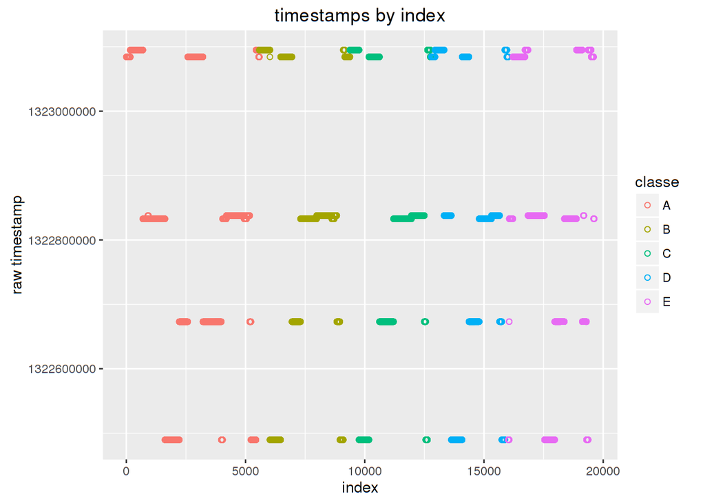

## Model summary

```r
print(rfFit)
```

```
## Random Forest
##
## 19622 samples
##    52 predictors
##     5 classes: 'A', 'B', 'C', 'D', 'E'
##
## No pre-processing
## Resampling: Cross-Validated (10 fold)
## Summary of sample sizes: 17659, 17659, 17659, 17660, 17661, 17659, ...
## Resampling results across tuning parameters:
##
##   mtry  Accuracy   Kappa      Accuracy SD  Kappa SD
##    2    0.9955148  0.9943262  0.001609769  0.002036903
##   27    0.9954130  0.9941974  0.001249978  0.001581671
##   52    0.9898581  0.9871694  0.001369676  0.001733055
##
## Accuracy was used to select the optimal model using  the largest value.
## The final value used for the model was mtry = 2.
```

```r
print(rfFit$finalModel)
```

```
##
## Call:
##  randomForest(x = x, y = y, mtry = param$mtry, proximity = TRUE,      allowParallel = FALSE)
##                Type of random forest: classification
##                      Number of trees: 500
## No. of variables tried at each split: 2
##
##         OOB estimate of  error rate: 0.44%
## Confusion matrix:
##      A    B    C    D    E  class.error
## A 5578    2    0    0    0 0.0003584229
## B   11 3782    4    0    0 0.0039504872
## C    0   20 3399    3    0 0.0067212157
## D    0    0   39 3174    3 0.0130597015
## E    0    0    0    5 3602 0.0013861935
```

```r
cm <- rfFit$finalModel$confusion
sens <- 100 * cm[1,1] / sum(cm[,1])
spec <- 100 * sum(cm[c(2:5),2:5]) / sum(cm[c(1:5),2:5])
print(c(sens, spec))
```

```
## [1] 99.80318 99.98575
```

## Variable importance

```r
data.frame(overall=rfFit$finalModel$importance[order(rfFit$finalModel$importance, decreasing = TRUE),])
```

```
##                       overall
## roll_belt            706.6507
## yaw_belt             629.7923
## magnet_dumbbell_z    559.6328
## magnet_dumbbell_y    511.0041
## pitch_belt           499.4745
## pitch_forearm        489.9517
## magnet_dumbbell_x    452.8284
## roll_forearm         424.2823
## accel_dumbbell_y     396.4638
## accel_belt_z         386.1391
## magnet_belt_z        383.4336
## roll_dumbbell        376.5844
## magnet_belt_y        372.0267
## accel_dumbbell_z     350.1756
## roll_arm             349.6218
## gyros_belt_z         317.9120
## accel_forearm_x      317.5656
## total_accel_dumbbell 313.1074
## accel_dumbbell_x     300.6491
## gyros_dumbbell_y     296.8324
## yaw_dumbbell         295.1742
## magnet_forearm_z     292.4779
## magnet_arm_y         283.1274
## magnet_forearm_x     278.8092
## accel_arm_x          277.4201
## magnet_arm_x         274.2732
## total_accel_belt     270.8986
## magnet_forearm_y     269.8338
## yaw_arm              268.8274
## pitch_dumbbell       266.1792
## magnet_belt_x        265.6356
## accel_forearm_z      261.9357
## pitch_arm            242.8751
## magnet_arm_z         241.0078
## yaw_forearm          229.1149
## accel_arm_y          221.7232
## gyros_arm_x          212.6209
## accel_forearm_y      208.7881
## accel_arm_z          206.6830
## gyros_arm_y          205.6810
## gyros_dumbbell_x     190.6607
## accel_belt_y         190.2584
## gyros_forearm_y      189.1475
## accel_belt_x         186.6017
## total_accel_forearm  173.1427
## total_accel_arm      172.8462
## gyros_belt_x         172.5940
## gyros_belt_y         171.2917
## gyros_forearm_x      143.9750
## gyros_dumbbell_z     143.1594
## gyros_forearm_z      141.8254
## gyros_arm_z          117.1929
```